# Practical Machine Learning Course Project

Kurt Fitz

August 24, 2020

## This document is the final project in the Coursera Practical Machine Learning course.

### Executive Summary

Using devices such as Jawbone Up, Nike FuelBand, and Fitbit it is now possible to collect a large amount of data about personal activity relatively inexpensively. These type of devices are part of the quantified self movement – a group of enthusiasts who take measurements about themselves regularly to improve their health, to find patterns in their behavior, or because they are tech geeks. One thing that people regularly do is quantify how much of a particular activity they do, but they rarely quantify how well they do it. The goal of this project is to use data collected from accelerometers on the belt, forearm, arm, and dumbell of 6 participants to classify whether barbell lifts were done correctly or not.

### Data Loading and Cleaning

Load the data and remove variables with near zero variance, mostly NA values, and columns not related to prediction data.

```r
#Load the dependencies
library(caret)
```

```r
library(e1071)
library(rpart)
library(rpart.plot)
#Read the data into memory
trainUrl<- "https://d396qusza40orc.cloudfront.net/predmachlearn/pml-training.csv"
testUrl<- "https://d396qusza40orc.cloudfront.net/predmachlearn/pml-testing.csv"

trainingData <- read.csv(url(trainUrl))
testData <- read.csv(url(testUrl))

dim(trainingData)
```

```
## [1] 19622   160
```

```r
dim(testData)
```

```
## [1]  20 160
```

```r
# remove any variables with near zero variance
nzv <- nearZeroVar(trainingData)

trainingSet <- trainingData[, -nzv]
testingSet <- testData[, -nzv]

dim(trainingSet)
```

```
## [1] 19622   100
```

```r
dim(testingSet)
```

```
## [1]  20 100
```

```r
# remove variables that are mostly NA
naCol <- sapply(trainingSet, function(x) mean(is.na(x))) > 0.95

trainingSet <- trainingSet[,naCol==FALSE]
testingSet  <- testingSet[,naCol==FALSE]

dim(trainingSet)
```

```
## [1] 19622    59
```

```r
dim(testingSet)
```

```
## [1] 20 59
```

```r
# remove first seven variables, as they have no predictive value.
trainingSet <- trainingSet[, (8:59)]
testingSet  <- testingSet[, (8:59)]

dim(trainingSet)
```

```
## [1] 19622    52
```

```r
dim(testingSet)
```

```
## [1] 20 52
```

```r
#convert classe column to factor variable for confusionMatrix compatability.
##trainingSet$classe <- as.factor(trainingSet$classe)
##testingSet$classe <- as.factor(testingSet$classe)

#partition data set
inTrain <- createDataPartition(trainingSet$classe, p=0.6, list=FALSE)

training <- trainingSet[inTrain,]
testing <- trainingSet[-inTrain,]
```

### Modeling

#### Gradient Boosting Model

```r
gbm_fit <- train(classe ~., data=training, method="gbm", verbose=FALSE)

gbm_fit$finalModel
```

```
## A gradient boosted model with multinomial loss function.
## 150 iterations were performed.
## There were 51 predictors of which 51 had non-zero influence.
```

Prediction using the GBM model

```r
gbm_predict <- predict(gbm_fit, testing)

gbm_predict_confMatrix <- confusionMatrix(gbm_predict, factor(testing$classe))

gbm_predict_confMatrix
```

```
## Confusion Matrix and Statistics
##
##           Reference
## Prediction    A    B    C    D    E
##          A 2194   53    1    1    3
##          B   24 1417   54    3   10
##          C   10   42 1286   41   22
##          D    4    0   23 1228   17
##          E    0    6    4   13 1390
##
## Overall Statistics
##
##                Accuracy : 0.9578
##                  95% CI : (0.9531, 0.9622)
##     No Information Rate : 0.2845
##     P-Value [Acc > NIR] : < 2.2e-16
##
##                   Kappa : 0.9466
##
##  Mcnemar's Test P-Value : 1.096e-06
##
## Statistics by Class:
##
##                      Class: A Class: B Class: C Class: D Class: E
## Sensitivity            0.9830   0.9335   0.9401   0.9549   0.9639
## Specificity            0.9897   0.9856   0.9822   0.9933   0.9964
## Pos Pred Value         0.9742   0.9397   0.9179   0.9654   0.9837
## Neg Pred Value         0.9932   0.9841   0.9873   0.9912   0.9919
## Prevalence             0.2845   0.1935   0.1744   0.1639   0.1838
## Detection Rate         0.2796   0.1806   0.1639   0.1565   0.1772
## Detection Prevalence   0.2870   0.1922   0.1786   0.1621   0.1801
## Balanced Accuracy      0.9863   0.9595   0.9612   0.9741   0.9802
```

Resulting plot

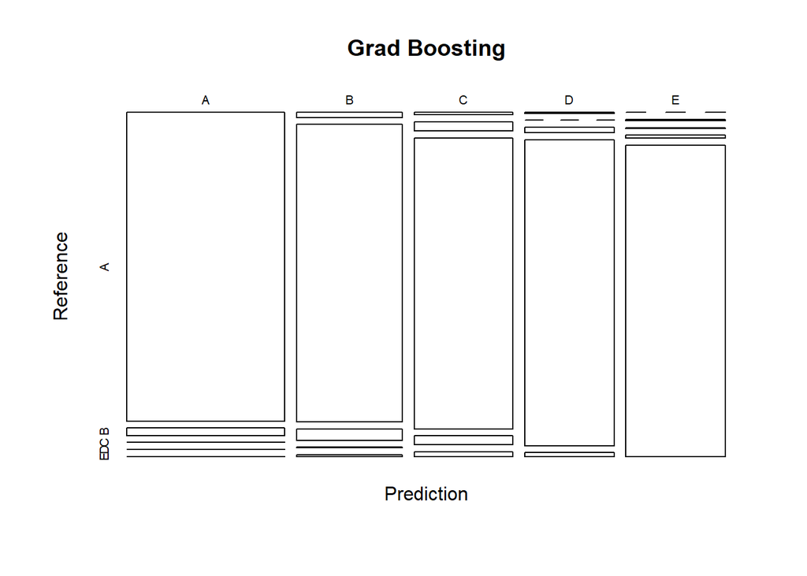

```r
plot(gbm_predict_confMatrix$table, col=gbm_predict_confMatrix$byClass, main="Grad Boosting")
```

#### Random Forest Model

```r
rf_fit <- train(classe ~., data=training, method="rf", ntree=125)
```

Prediction using the Random Forest Model

```r
rf_predict <- predict(rf_fit, testing)

rf_predict_confMatrix <- confusionMatrix(rf_predict, factor(testing$classe))

rf_predict_confMatrix
```

```
## Confusion Matrix and Statistics
##
##           Reference
## Prediction    A    B    C    D    E
##          A 2224    9    0    0    0
##          B    7 1504   11    0    0
##          C    0    5 1352   13    3
##          D    1    0    5 1272    2
##          E    0    0    0    1 1437
##
## Overall Statistics
##
##                Accuracy : 0.9927
##                  95% CI : (0.9906, 0.9945)
##     No Information Rate : 0.2845
##     P-Value [Acc > NIR] : < 2.2e-16
##
##                   Kappa : 0.9908
##
##  Mcnemar's Test P-Value : NA
##
## Statistics by Class:
##
##                      Class: A Class: B Class: C Class: D Class: E
## Sensitivity            0.9964   0.9908   0.9883   0.9891   0.9965
## Specificity            0.9984   0.9972   0.9968   0.9988   0.9998
## Pos Pred Value         0.9960   0.9882   0.9847   0.9938   0.9993
## Neg Pred Value         0.9986   0.9978   0.9975   0.9979   0.9992
## Prevalence             0.2845   0.1935   0.1744   0.1639   0.1838
## Detection Rate         0.2835   0.1917   0.1723   0.1621   0.1832
## Detection Prevalence   0.2846   0.1940   0.1750   0.1631   0.1833
## Balanced Accuracy      0.9974   0.9940   0.9925   0.9939   0.9982
```

Resulting Plot

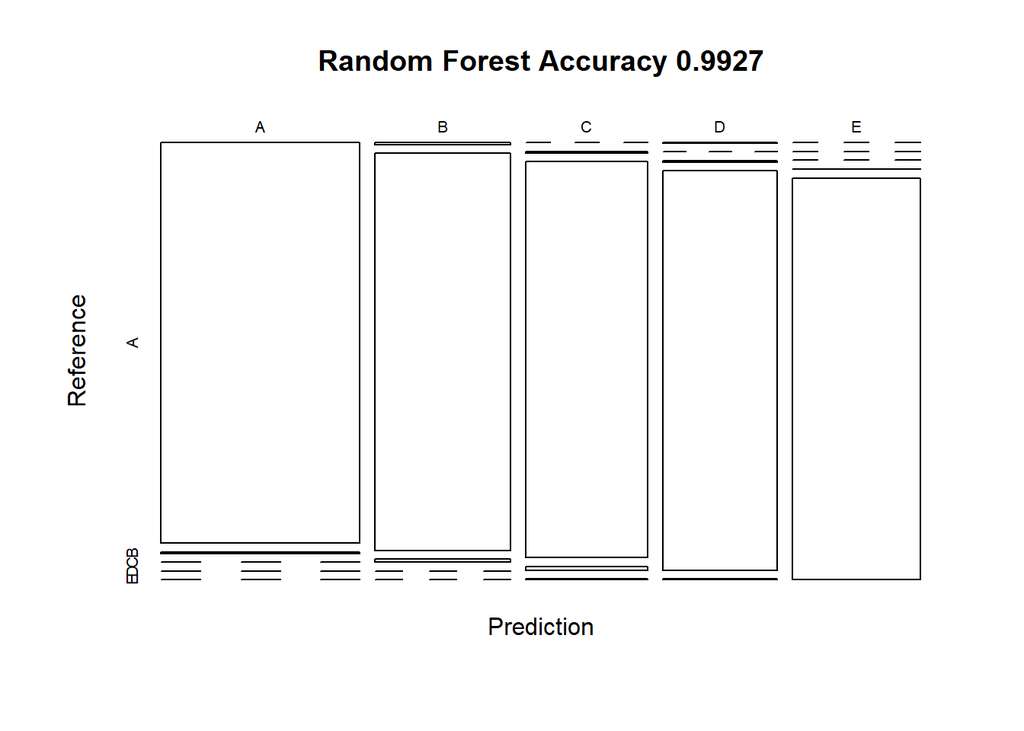

```r
plot(rf_predict_confMatrix$table, col=rf_predict_confMatrix$byClass,
     main=paste("Random Forest Accuracy",
                round(rf_predict_confMatrix$overall['Accuracy'],
                      4)))
```

#### Decision Tree Model

```r
#set.seed(3344)
dt_fit <- train(classe ~., data=training, method="rpart")
```

Prediction using the trained decision tree.

```r
dt_predict <- predict(dt_fit, testing)

dt_confMatrix <- confusionMatrix(dt_predict, factor(testing$classe))

dt_confMatrix
```

```
## Confusion Matrix and Statistics
##
##           Reference
## Prediction    A    B    C    D    E
##          A 1816  391   68  127   70
##          B   45  694   57   97  300
##          C  331  307 1067  665  458
##          D   38  126  160  397    6
##          E    2    0   16    0  608
##
## Overall Statistics
##
##                Accuracy : 0.584
##                  95% CI : (0.573, 0.5949)
##     No Information Rate : 0.2845
##     P-Value [Acc > NIR] : < 2.2e-16
##
##                   Kappa : 0.4722
##
##  Mcnemar's Test P-Value : < 2.2e-16
##
## Statistics by Class:
##
##                      Class: A Class: B Class: C Class: D Class: E
## Sensitivity            0.8136  0.45718   0.7800  0.30871  0.42164
## Specificity            0.8831  0.92114   0.7282  0.94970  0.99719
## Pos Pred Value         0.7346  0.58173   0.3773  0.54608  0.97125
## Neg Pred Value         0.9226  0.87615   0.9400  0.87512  0.88449
## Prevalence             0.2845  0.19347   0.1744  0.16391  0.18379
## Detection Rate         0.2315  0.08845   0.1360  0.05060  0.07749
## Detection Prevalence   0.3151  0.15205   0.3604  0.09266  0.07979
## Balanced Accuracy      0.8484  0.68916   0.7541  0.62920  0.70941
```

Result Plot

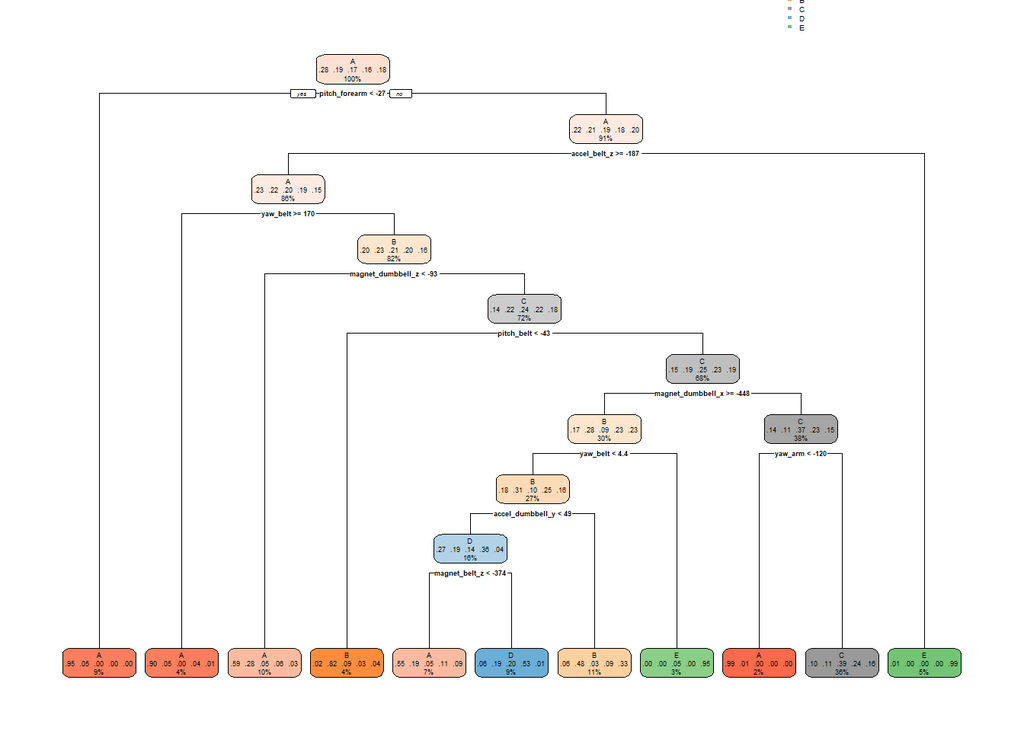

```r
rpart.plot(dt_fit$finalModel, roundint=FALSE)
```

### Conclusion

After analyzing the results of the above three models, it appears that the Random Forest model is the most accurate for predicting whether the exercises were performed correctly.